# Building A Linear Reservoir From Scratch

Today we will build a simple hydrological model.

The model is called a **linear reservoir**.

It has one storage:

```
storage_mm
```

It has one parameter:

```
residence_time_days
```

The model says:

```
outflow = storage / residence time
new storage = old storage + inflow - outflow
```

We will start with one day, then many days, then a reusable model function.

# Построение линейного резервуара с нуля

Сегодня мы шаг за шагом построим простую гидрологическую модель.

Эта модель называется **линейный резервуар**.

У нее есть одно хранилище:

```
storage_mm
```

И один параметр:

```
residence_time_days
```

Модель задается так:

```
outflow = storage / residence time
new storage = old storage + inflow - outflow
```

Мы начнем с одного дня, затем перейдем к нескольким дням, а потом оформим модель как функцию, которую можно использовать повторно.

## Python Environment

In VS Code, open a terminal.

On Windows PowerShell:

```
py -m venv .venv
.venv\Scripts\Activate.ps1
python -m pip install ipykernel numpy matplotlib pandas
```

On macOS or Linux:

```
python3 -m venv .venv
source .venv/bin/activate
python -m pip install ipykernel numpy matplotlib pandas
```

Then select the `.venv` kernel in this notebook.

## Среда Python

В VS Code откройте терминал.

В Windows PowerShell:

```
py -m venv .venv
.venv\Scripts\Activate.ps1
python -m pip install ipykernel numpy matplotlib pandas
```

В macOS или Linux:

```
python3 -m venv .venv
source .venv/bin/activate
python -m pip install ipykernel numpy matplotlib pandas
```

Затем выберите ядро `.venv` для этого ноутбука.

## 1. One Reservoir Timestep By Hand

Let us begin with one day.

The reservoir starts with `50 mm` of water in storage.

The residence time is `10 days`.

Today, `4 mm` of water enters the reservoir.

We use `storage_before_mm` and `storage_after_mm` so it is clear which storage belongs to which moment in time.

## 1. Один шаг резервуара вручную

Начнем с одного дня.

В начале в резервуаре хранится `50 mm` воды.

Время пребывания воды равно `10 days`.

Сегодня в резервуар поступает `4 mm` воды.

Мы используем `storage_before_mm` и `storage_after_mm`, чтобы было ясно, к какому моменту времени относится хранилище.

```python
storage_before_mm = 50.0
residence_time_days = 10.0
inflow_mm = 4.0

outflow_mm = storage_before_mm / residence_time_days
storage_after_mm = storage_before_mm + inflow_mm - outflow_mm

print("outflow:", outflow_mm, "mm/day")
print("storage after:", storage_after_mm, "mm")
```

```
outflow: 5.0 mm/day
storage after: 49.0 mm
```

This is one model timestep.

The storage before the step was `50 mm`.

Because `residence_time_days = 10`, one tenth of the storage leaves in one day.

The inflow was `4 mm`.

So the reservoir loses `5 mm`, gains `4 mm`, and ends with `49 mm`.

Это один временной шаг модели.

Хранилище до шага было равно `50 mm`.

Поскольку `residence_time_days = 10`, за один день из резервуара выходит одна десятая хранилища.

Приток был равен `4 mm`.

Поэтому резервуар теряет `5 mm`, получает `4 mm` и заканчивает день с `49 mm`.

## 2. A Second Day Creates The Idea Of State

Now we simulate a second day.

The storage after day 1 becomes the storage before day 2.

## 2. Второй день вводит идею состояния

Теперь смоделируем второй день.

Хранилище после дня 1 становится хранилищем до дня 2.

```python
storage_before_mm = storage_after_mm
inflow_mm = 0.0

outflow_mm = storage_before_mm / residence_time_days
storage_after_mm = storage_before_mm + inflow_mm - outflow_mm

print("outflow:", outflow_mm, "mm/day")
print("storage after:", storage_after_mm, "mm")
```

```
outflow: 4.9 mm/day
storage after: 44.1 mm
```

The model has memory.

The result from day 1 becomes the starting point for day 2.

That changing memory is called the **state** of the model.

У модели есть память.

Результат дня 1 становится начальной точкой для дня 2.

Эта изменяющаяся память называется **состоянием** модели.

## 3. Many Days Create The Need For Lists And Loops

Copying the same equations once per day would be painful.

Instead, we store several days of inflow in a list.

## 3. Несколько дней создают потребность в списках и циклах

Копировать одни и те же уравнения для каждого дня было бы неудобно.

Вместо этого мы сохраним приток за несколько дней в список.

```python
inflow_series_mm = [4.0, 0.0, 12.0, 2.0, 0.0]

print(inflow_series_mm)
```

```
[4.0, 0.0, 12.0, 2.0, 0.0]
```

```python
storage_before_mm = 50.0
residence_time_days = 10.0

for inflow_mm in inflow_series_mm:
    outflow_mm = storage_before_mm / residence_time_days
    storage_after_mm = storage_before_mm + inflow_mm - outflow_mm

    print("inflow:", inflow_mm, "outflow:", outflow_mm, "storage after:", storage_after_mm)

    storage_before_mm = storage_after_mm
```

```
inflow: 4.0 outflow: 5.0 storage after: 49.0
inflow: 0.0 outflow: 4.9 storage after: 44.1
inflow: 12.0 outflow: 4.41 storage after: 51.69
inflow: 2.0 outflow: 5.169 storage after: 48.521
inflow: 0.0 outflow: 4.8521 storage after: 43.6689
```

The loop repeats the same model step for each inflow value.

At the end of each day, we update `storage_before_mm`.

That updated storage becomes the starting storage for the next day.

Цикл повторяет один и тот же шаг модели для каждого значения притока.

В конце каждого дня мы обновляем `storage_before_mm`.

Это обновленное хранилище становится начальным хранилищем для следующего дня.

## 4. Store The Simulation Output

Printing is useful while we are learning, but it does not give us a result we can plot or analyze.

So we store the simulated storage and outflow in lists.

## 4. Сохраняем результат симуляции

Печать значений полезна, когда мы учимся, но она не дает нам результата, который удобно строить на графике или анализировать.

Поэтому мы сохраняем смоделированные хранилище и отток в списки.

```python
storage_before_mm = 50.0
residence_time_days = 10.0

storage_series_mm = []
outflow_series_mm = []

for inflow_mm in inflow_series_mm:
    outflow_mm = storage_before_mm / residence_time_days
    storage_after_mm = storage_before_mm + inflow_mm - outflow_mm

    storage_series_mm.append(storage_after_mm)
    outflow_series_mm.append(outflow_mm)

    storage_before_mm = storage_after_mm

print("storage:", storage_series_mm)
print("outflow:", outflow_series_mm)
```

```
storage: [49.0, 44.1, 51.69, 48.521, 43.6689]
outflow: [5.0, 4.9, 4.41, 5.169, 4.8521]
```

Now we have a simulated time series.

This is the first real model output.

Теперь у нас есть смоделированный временной ряд.

Это первый настоящий результат модели.

## 5. Plot The Toy Simulation

A plot helps us see how storage and outflow change through time.

## 5. Строим график простой симуляции

График помогает увидеть, как хранилище и отток меняются во времени.

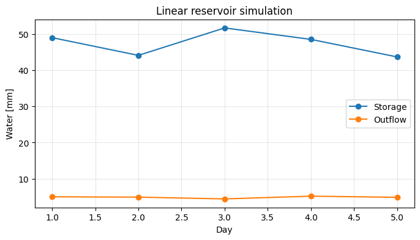

```python
import matplotlib.pyplot as plt

days = [1, 2, 3, 4, 5]

fig, ax = plt.subplots(figsize=(8, 4))

ax.plot(days, storage_series_mm, marker="o", label="Storage")
ax.plot(days, outflow_series_mm, marker="o", label="Outflow")

ax.set_xlabel("Day")
ax.set_ylabel("Water [mm]")
ax.set_title("Linear reservoir simulation")
ax.grid(alpha=0.3)
ax.legend()

plt.show()
```

## 6. One Timestep Becomes A Function

The loop works, but the model equations are hidden inside it.

The hydrological idea has a name:

```
one timestep of the reservoir
```

So we put one timestep into a function.

## 6. Один временной шаг становится функцией

Цикл работает, но уравнения модели спрятаны внутри него.

У этой гидрологической идеи есть название:

```
one timestep of the reservoir
```

Поэтому мы помещаем один временной шаг в функцию.

```python
def step(
    storage_before_mm: float,
    residence_time_days: float,
    inflow_mm: float,
) -> tuple[float, float]:
    outflow_mm = storage_before_mm / residence_time_days
    storage_after_mm = storage_before_mm + inflow_mm - outflow_mm
    return storage_after_mm, outflow_mm
```

```python
storage_after_mm, outflow_mm = step(
    storage_before_mm=50.0,
    residence_time_days=10.0,
    inflow_mm=4.0,
)

print(storage_after_mm)
print(outflow_mm)
```

```
49.0
5.0
```

The function separates the model equation from the time loop.

`step()` answers one question: given the storage before the timestep, the residence time, and the inflow, what is the storage after the timestep and today's outflow?

Функция отделяет уравнение модели от цикла по времени.

`step()` отвечает на один вопрос: если известны хранилище до временного шага, время пребывания и приток, каким будет хранилище после временного шага и сегодняшний отток?

## 7. Many Timesteps Become A Run Function

Now we write one function for the full simulation.

The `step()` function simulates one day.

The `run_linear_reservoir()` function simulates a full time series.

## 7. Несколько временных шагов становятся функцией запуска модели

Теперь мы напишем одну функцию для всей симуляции.

Функция `step()` моделирует один день.

Функция `run_linear_reservoir()` моделирует полный временной ряд.

```python
def run_linear_reservoir(
    initial_storage_mm: float,
    residence_time_days: float,
    inflow_series_mm: list[float],
) -> tuple[list[float], list[float]]:
    storage_before_mm = initial_storage_mm

    storage_series_mm = []
    outflow_series_mm = []

    for inflow_mm in inflow_series_mm:
        storage_after_mm, outflow_mm = step(
            storage_before_mm=storage_before_mm,
            residence_time_days=residence_time_days,
            inflow_mm=inflow_mm,
        )

        storage_series_mm.append(storage_after_mm)
        outflow_series_mm.append(outflow_mm)

        storage_before_mm = storage_after_mm

    return storage_series_mm, outflow_series_mm
```

```python
storage_series_mm, outflow_series_mm = run_linear_reservoir(
    initial_storage_mm=50.0,
    residence_time_days=10.0,
    inflow_series_mm=inflow_series_mm,
)

print(storage_series_mm)
print(outflow_series_mm)
```

```
[49.0, 44.1, 51.69, 48.521, 43.6689]
[5.0, 4.9, 4.41, 5.169, 4.8521]
```

Now the model has two levels:

- `step()` simulates one day
- `run_linear_reservoir()` simulates a full time series

This is a common structure in hydrological modelling.

Теперь у модели есть два уровня:

- `step()` моделирует один день
- `run_linear_reservoir()` моделирует полный временной ряд

Это распространенная структура в гидрологическом моделировании.

## 8. Intermezzo: NumPy Arrays And Positions

Earlier, we stored results with `.append()`.

That worked because Python lists can grow:

```
outflow_series_mm.append(outflow_mm)
```

For longer numerical simulations, we often use NumPy arrays.

With NumPy, we usually create the full output array first.

Then we fill one position at a time.

To do that, we need two things during the loop:

- the position number
- the value at that position

`enumerate(...)` gives us both.

## 8. Интермеццо: массивы NumPy и позиции

Раньше мы сохраняли результаты с помощью `.append()`.

Это работало, потому что списки Python могут расти:

```
outflow_series_mm.append(outflow_mm)
```

Для более длинных численных симуляций мы часто используем массивы NumPy.

В NumPy обычно сначала создают весь выходной массив.

Затем мы заполняем по одной позиции за раз.

Для этого в цикле нам нужны две вещи:

- номер позиции
- значение в этой позиции

`enumerate(...)` дает нам и то, и другое.

```python
import numpy as np

example_inflow = np.array([4.0, 0.0, 12.0])

for i, inflow_mm in enumerate(example_inflow):
    print("position:", i, "value:", inflow_mm)
```

```
position: 0 value: 4.0
position: 1 value: 0.0
position: 2 value: 12.0
```

```python
example_outflow = np.zeros(len(example_inflow))

for i, inflow_mm in enumerate(example_inflow):
    example_outflow[i] = inflow_mm * 0.5

print(example_outflow)
```

```
[2. 0. 6.]
```

```python
def run_linear_reservoir(
    initial_storage_mm: float,
    residence_time_days: float,
    inflow_series_mm: np.ndarray,
) -> tuple[np.ndarray, np.ndarray]:
    storage_series_mm = np.zeros(len(inflow_series_mm))
    outflow_series_mm = np.zeros(len(inflow_series_mm))

    storage_before_mm = initial_storage_mm

    for i, inflow_mm in enumerate(inflow_series_mm):
        storage_after_mm, outflow_mm = step(
            storage_before_mm=storage_before_mm,
            residence_time_days=residence_time_days,
            inflow_mm=inflow_mm,
        )

        storage_series_mm[i] = storage_after_mm
        outflow_series_mm[i] = outflow_mm

        storage_before_mm = storage_after_mm

    return storage_series_mm, outflow_series_mm
```

## 9. Main Experiment: Pulse Response

Now we do a controlled experiment.

We put `100 mm` of water into the reservoir on the first day.

Then we watch how the reservoir drains.

This helps us understand what `residence_time_days` controls.

## 9. Главный эксперимент: отклик на импульс

Теперь проведем контролируемый эксперимент.

В первый день мы помещаем в резервуар `100 mm` воды.

Затем наблюдаем, как резервуар опорожняется.

Это помогает понять, чем управляет `residence_time_days`.

```python
n_days = 60

inflow_series_mm = np.zeros(n_days)
inflow_series_mm[0] = 100.0

days = np.arange(n_days)

print(inflow_series_mm[:10])
```

```
[100.   0.   0.   0.   0.   0.   0.   0.   0.   0.]
```

```python
storage_mm, outflow_mm = run_linear_reservoir(
    initial_storage_mm=0.0,
    residence_time_days=10.0,
    inflow_series_mm=inflow_series_mm,
)

print("peak outflow:", outflow_mm.max())
print("final storage:", storage_mm[-1])
```

```
peak outflow: 10.0
final storage: 0.19966781110160348
```

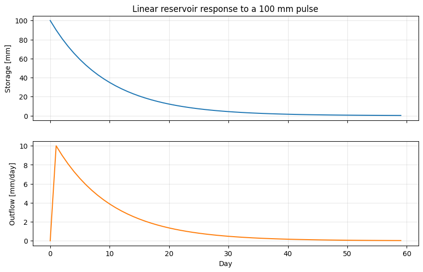

```python
fig, (ax_storage, ax_outflow) = plt.subplots(
    2,
    1,
    figsize=(10, 6),
    sharex=True,
)

ax_storage.plot(days, storage_mm, color="tab:blue")
ax_storage.set_ylabel("Storage [mm]")
ax_storage.set_title("Linear reservoir response to a 100 mm pulse")
ax_storage.grid(alpha=0.3)

ax_outflow.plot(days, outflow_mm, color="tab:orange")
ax_outflow.set_xlabel("Day")
ax_outflow.set_ylabel("Outflow [mm/day]")
ax_outflow.grid(alpha=0.3)

plt.show()
```

## 10. Compare Different Residence Times

Now we run the same pulse experiment with three different values of `residence_time_days`.

## 10. Сравниваем разные времена пребывания

Теперь запускаем тот же импульсный эксперимент с тремя разными значениями `residence_time_days`.

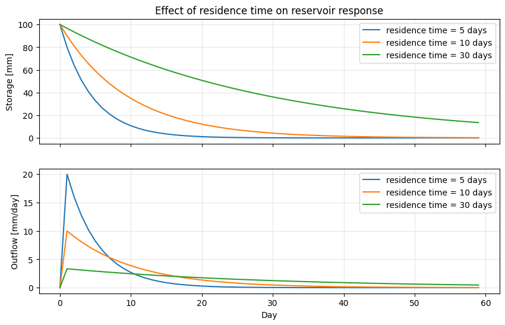

```python
residence_times_days = [5.0, 10.0, 30.0]

fig, (ax_storage, ax_outflow) = plt.subplots(
    2,
    1,
    figsize=(10, 6),
    sharex=True,
)

for residence_time_days in residence_times_days:
    storage_mm, outflow_mm = run_linear_reservoir(
        initial_storage_mm=0.0,
        residence_time_days=residence_time_days,
        inflow_series_mm=inflow_series_mm,
    )

    ax_storage.plot(days, storage_mm, label=f"residence time = {residence_time_days:.0f} days")
    ax_outflow.plot(days, outflow_mm, label=f"residence time = {residence_time_days:.0f} days")

ax_storage.set_ylabel("Storage [mm]")
ax_storage.set_title("Effect of residence time on reservoir response")
ax_storage.grid(alpha=0.3)
ax_storage.legend()

ax_outflow.set_xlabel("Day")
ax_outflow.set_ylabel("Outflow [mm/day]")
ax_outflow.grid(alpha=0.3)
ax_outflow.legend()

plt.show()
```

Small `residence_time_days`:

- water leaves quickly
- peak outflow is high
- recession is steep

Large `residence_time_days`:

- water leaves slowly
- peak outflow is lower
- recession is longer

The residence time controls the timing of runoff.

Малое `residence_time_days`:

- вода выходит быстро
- пик оттока высокий
- спад резкий

Большое `residence_time_days`:

- вода выходит медленно
- пик оттока ниже
- спад длиннее

Время пребывания управляет временем формирования стока.

## 11. Optional: Real Alamedin Precipitation

The pulse experiment helped us understand the model.

Now we can drive the same model with real daily precipitation.

## 11. Дополнительно: реальные осадки Аламедина

Эксперимент с импульсом помог нам понять модель.

Теперь мы можем запустить ту же модель на реальных суточных осадках.

```python
from pathlib import Path

import pandas as pd

PROJECT_ROOT = Path.cwd()
if not (PROJECT_ROOT / "data").exists():
    PROJECT_ROOT = PROJECT_ROOT.parent

DATA_ROOT = PROJECT_ROOT / "data" / "02_data"
ALAMEDIN_FOLDER = DATA_ROOT / "15189_Alamedin_River_KGZ"

precip_path = ALAMEDIN_FOLDER / "02_forcing" / "era5_precipitation_daily.csv"

print(precip_path)
print(precip_path.exists())
```

```
data/02_data/15189_Alamedin_River_KGZ/02_forcing/era5_precipitation_daily.csv
True
```

```python
precip_df = pd.read_csv(precip_path, parse_dates=["date"])
precip_2015_df = precip_df.loc[precip_df["date"].dt.year == 2015].copy()

print("rows:", len(precip_2015_df))
print("annual precipitation:", precip_2015_df["precipitation_mm"].sum())

precip_2015_df.head()
```

```
rows: 365
annual precipitation: 1276.8017
```

|  | date | precipitation_mm |
| --- | --- | --- |
| 12418 | 2015-01-01 | 0.0070 |
| 12419 | 2015-01-02 | 1.7699 |
| 12420 | 2015-01-03 | 0.5198 |
| 12421 | 2015-01-04 | 0.1958 |
| 12422 | 2015-01-05 | 0.9147 |

```python
inflow_2015_mm = precip_2015_df["precipitation_mm"].values

storage_2015_mm, simulated_q_2015_mm = run_linear_reservoir(
    initial_storage_mm=0.0,
    residence_time_days=15.0,
    inflow_series_mm=inflow_2015_mm,
)

precip_2015_df["storage_mm"] = storage_2015_mm
precip_2015_df["simulated_q_mm"] = simulated_q_2015_mm
```

```python
q_path = ALAMEDIN_FOLDER / "03_processed" / "alamedin_cleaned_daily.csv"
q_df = pd.read_csv(q_path, parse_dates=["date"])

q_2015_df = q_df.loc[
    (q_df["date"].dt.year == 2015)
    & (q_df["q_status"] == "observed")
].copy()

print("observed rows:", len(q_2015_df))
print("annual observed Q:", q_2015_df["q_mm_clean"].sum())
print("annual simulated Q:", precip_2015_df["simulated_q_mm"].sum())

q_2015_df.head()
```

```
observed rows: 365
annual observed Q: 540.8842410336915
annual simulated Q: 1264.7956809895272
```

|  | date | q_m3s | q_mm | gap_length_days | q_m3s_clean | q_status | q_mm_clean |
| --- | --- | --- | --- | --- | --- | --- | --- |
| 5479 | 2015-01-01 | 1.86 | 0.388127 | 0 | 1.86 | observed | 0.388127 |
| 5480 | 2015-01-02 | 1.88 | 0.392300 | 0 | 1.88 | observed | 0.392300 |
| 5481 | 2015-01-03 | 1.90 | 0.396474 | 0 | 1.90 | observed | 0.396474 |
| 5482 | 2015-01-04 | 1.92 | 0.400647 | 0 | 1.92 | observed | 0.400647 |
| 5483 | 2015-01-05 | 1.93 | 0.402734 | 0 | 1.93 | observed | 0.402734 |

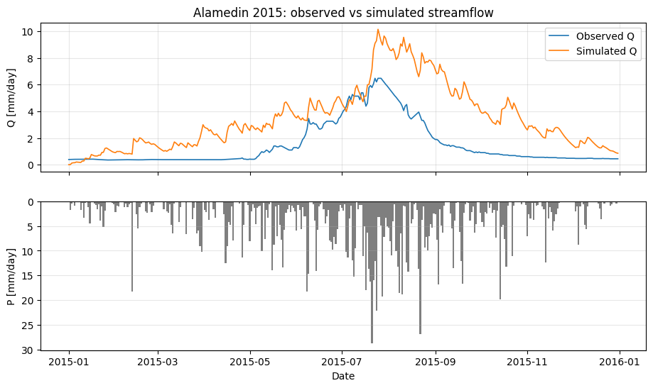

```python
fig, (ax_q, ax_p) = plt.subplots(
    2,
    1,
    figsize=(11, 6),
    sharex=True,
)

ax_q.plot(
    q_2015_df["date"],
    q_2015_df["q_mm_clean"],
    color="tab:blue",
    linewidth=1.2,
    label="Observed Q",
)

ax_q.plot(
    precip_2015_df["date"],
    precip_2015_df["simulated_q_mm"],
    color="tab:orange",
    linewidth=1.2,
    label="Simulated Q",
)

ax_q.set_ylabel("Q [mm/day]")
ax_q.set_title("Alamedin 2015: observed vs simulated streamflow")
ax_q.grid(alpha=0.3)
ax_q.legend()

ax_p.bar(
    precip_2015_df["date"],
    precip_2015_df["precipitation_mm"],
    color="tab:gray",
    width=1.0,
)

ax_p.set_ylabel("P [mm/day]")
ax_p.set_xlabel("Date")
ax_p.grid(axis="y", alpha=0.3)
ax_p.invert_yaxis()

plt.show()
```

This model is useful, but incomplete.

It has no:

- evapotranspiration
- snow accumulation
- snowmelt
- glacier melt
- soil moisture limit
- calibration

But the structure is already the structure of a hydrological model:

```
forcing -> step -> storage update -> streamflow
```

Эта модель полезна, но неполна.

В ней нет:

- эвапотранспирации
- накопления снега
- снеготаяния
- таяния ледников
- ограничения почвенной влаги
- калибровки

Но ее структура уже соответствует структуре гидрологической модели:

```
forcing -> step -> storage update -> streamflow
```

## Final Discussion Questions

1. What does `residence_time_days` control?
2. What happens when `residence_time_days` is small?
3. What happens when `residence_time_days` is large?
4. Why is a `step()` function useful?
5. Why is a `run_linear_reservoir()` function useful?
6. What processes should we add next?

## Итоговые вопросы для обсуждения

1. Чем управляет `residence_time_days`?
2. Что происходит, когда `residence_time_days` маленькое?
3. Что происходит, когда `residence_time_days` большое?
4. Почему функция `step()` полезна?
5. Почему функция `run_linear_reservoir()` полезна?
6. Какие процессы стоит добавить дальше?